# CS 1675 Final Project: Part 2B

Regression Models

Anastasia Sosnovskikh

## Load packages

Load the packages used for EDA.

```r
library(tidyverse)
```

```r
library(dplyr)
library(ggplot2)
library(caret)
library(coefplot)
```

## Load Data

Read in the data.

```r
data_url <- 'https://raw.githubusercontent.com/jyurko/CS_1675_Fall_2020/master/HW/final_project/cs_1675_final_project_data.csv'

df_raw <- readr::read_csv(data_url, col_names = TRUE)
```

Separate the variables associated with Step 1.

```r
df_step1_inputs <- df_raw %>% select(xA, xB, x01:x06, response_1)
```

Separate the variables associated with the Option B classification formulation. The `outcome_2` variable is converted to a factor with a specific ordering of the levels. This ordering is used when modeling in `caret` to make sure everyone predicts the `Fail` class as the “positive” class in the confusion matrix.

```r
df_step2_B_inputs <- df_raw %>% select(xA, xB, response_1, x07:x11, outcome_2) %>%
  mutate(outcome_2 = factor(outcome_2, levels = c('Fail', 'Pass')))
```

Separate the variables associated with the Option A classification formulation. The `outcome_2` variable is again converted to a factor with a specific ordering of the levels.

```r
df_step2_A_inputs <- df_raw %>% select(xA, xB, x01:x11, outcome_2) %>%
  mutate(outcome_2 = factor(outcome_2, levels = c('Fail', 'Pass')))
```

Change data types for the whole data frame to perform EDA.

```r
df <- df_raw %>%
  mutate(xA = as.factor(xA),
         xB = as.factor(xB),
         outcome_2 = factor(outcome_2, levels = c('Fail', 'Pass')))
```

Standardize the data.

```r
get_standardized <- function(df) {
  predict(preProcess(df, method = c('center', 'scale')), df)
}

df_step1_inputs_stand <- df_step1_inputs %>%  get_standardized()
df_step2_A_inputs_stand <- df_step2_A_inputs %>% get_standardized()
df_step2_B_inputs_stand <- df_step2_B_inputs %>%  get_standardized()
df_stand <- df %>% get_standardized()
```

Some helper functions to get the features of a particular type.

```r
get_CATEGORICAL_features_list <- function(df){
  colnames(df)[grepl('factor|logical|character',sapply(df,class))]
}
```

```r
get_CONTINIOUS_features_list <- function(df){
  df %>% select(-get_CATEGORICAL_features_list(df)) %>% colnames()
}
```

## Helpful functions

Visualize the coefficients

```r
show_coef <- function(mod_obj){
  mod_obj %>%
    coefplot::coefplot() +
    theme_bw()
}
```

Extract Metrics

```r
extract_metrics <- function(mod_obj, mod_name)
{
  broom::glance(mod_obj) %>%
    mutate(model_name = mod_name)
}
```

## Fit Linear Models

Use **Bayesian linear models** to fit 2 of the models you fit with `lm()`.

### 1. Laplace Approximation approach

#### Get the data set up

##### 1. all step 1 inputs – additive terms.

Read in the model.

```r
mod_lm_all <- readr::read_rds('mod_lm_all.rds')
mod_lm_all
```

```
##
## Call:
## lm(formula = response_1 ~ x01 + x02 + x03 + x04 + x05 + x06 +
##     xA + xB, data = df_step1_inputs_stand)
##
## Coefficients:
## (Intercept)          x01          x02          x03          x04          x05
##    0.521443     0.274688    -0.372295     0.035693     0.019350    -0.003949
##         x06         xAA2         xBB2         xBB3         xBB4
##   -0.010734     0.079972    -0.445411    -1.455420    -0.235481
```

Create the design matrix.

```r
Xmat_all <- model.matrix(response_1 ~ .,
                         data = df_step1_inputs_stand)

Xmat_all %>% head()
```

```
##   (Intercept) xAA2 xBB2 xBB3 xBB4        x01         x02        x03        x04
## 1           1    0    0    0    0 -0.9501694  0.57707618  0.2535556  0.1526743
## 2           1    0    0    0    0 -0.8347420  0.58110021 -2.1604047 -0.9386020
## 3           1    0    0    0    0  1.3614015  2.16557515 -0.4592955 -0.4672428
## 4           1    0    0    0    0 -0.5060454  1.33028532  0.8395294  0.2409399
## 5           1    0    0    0    0  0.5956374 -0.03752002 -0.6916267 -0.7021921
## 6           1    0    0    0    0 -1.6234939 -0.87677576 -2.1030035 -2.5549660
##           x05        x06
## 1 -0.55360912 -1.4173950
## 2 -0.78345419  0.3988716
## 3 -0.09497365 -2.1626542
## 4 -1.75573728  2.7914282
## 5  0.65105641 -0.7374690
## 6 -3.31908886 -1.4088579
```

Create a list of names.

```r
all_coef_names <- Xmat_all[,2:ncol(Xmat_all)] %>% colnames()
all_coef_names
```

```
##  [1] "xAA2" "xBB2" "xBB3" "xBB4" "x01"  "x02"  "x03"  "x04"  "x05"  "x06"
```

Create a list of inputs.

```r
info_all <- list(
  yobs = df_step1_inputs_stand$response_1,
  design_matrix = Xmat_all,
  mu_beta = 0,
  tau_beta = 5,
  sigma_rate = 1
)
```

##### 2. A basis function (interactions).

Read in the model.

```r
mod_lm_basis <- readr::read_rds('mod_lm_basis.rds')
mod_lm_basis
```

```
##
## Call:
## lm(formula = response_1 ~ (x01 + x02 + x03 + xB)^2, data = df_step1_inputs_stand)
##
## Coefficients:
## (Intercept)          x01          x02          x03         xBB2         xBB3
##    0.505309     0.093749    -0.448104    -0.089248    -0.382706    -1.277857
##        xBB4      x01:x02      x01:x03     x01:xBB2     x01:xBB3     x01:xBB4
##   -0.174863    -0.084817     0.122820     0.094362     0.412808     0.227579
##     x02:x03     x02:xBB2     x02:xBB3     x02:xBB4     x03:xBB2     x03:xBB3
##   -0.007681     0.141393     0.140804     0.022037     0.104007     0.266014
##    x03:xBB4
##    0.139982
```

Create the design matrix.

```r
Xmat_basis <- model.matrix(response_1 ~ (x01 + x02 + x03 + xB)^2,
                           data = df_step1_inputs_stand)

Xmat_basis %>% head()
```

```
##   (Intercept)        x01         x02        x03 xBB2 xBB3 xBB4     x01:x02
## 1           1 -0.9501694  0.57707618  0.2535556    0    0    0 -0.54832016
## 2           1 -0.8347420  0.58110021 -2.1604047    0    0    0 -0.48506877
## 3           1  1.3614015  2.16557515 -0.4592955    0    0    0  2.94821727
## 4           1 -0.5060454  1.33028532  0.8395294    0    0    0 -0.67318477
## 5           1  0.5956374 -0.03752002 -0.6916267    0    0    0 -0.02234833
## 6           1 -1.6234939 -0.87677576 -2.1030035    0    0    0  1.42344009
##      x01:x03 x01:xBB2 x01:xBB3 x01:xBB4     x02:x03 x02:xBB2 x02:xBB3 x02:xBB4
## 1 -0.2409207        0        0        0  0.14632087        0        0        0
## 2  1.8033806        0        0        0 -1.25541163        0        0        0
## 3 -0.6252856        0        0        0 -0.99463890        0        0        0
## 4 -0.4248400        0        0        0  1.11681370        0        0        0
## 5 -0.4119587        0        0        0  0.02594985        0        0        0
## 6  3.4142134        0        0        0  1.84386253        0        0        0
##   x03:xBB2 x03:xBB3 x03:xBB4
## 1        0        0        0
## 2        0        0        0
## 3        0        0        0
## 4        0        0        0
## 5        0        0        0
## 6        0        0        0
```

Create a list of names.

```r
basis_coef_names <- Xmat_basis[,2:ncol(Xmat_basis)] %>% colnames()
basis_coef_names
```

```
##  [1] "x01"      "x02"      "x03"      "xBB2"     "xBB3"     "xBB4"
##  [7] "x01:x02"  "x01:x03"  "x01:xBB2" "x01:xBB3" "x01:xBB4" "x02:x03"
## [13] "x02:xBB2" "x02:xBB3" "x02:xBB4" "x03:xBB2" "x03:xBB3" "x03:xBB4"
```

Create a list of inputs.

```r
info_basis <- list(yobs = df_step1_inputs_stand$response_1,
  design_matrix = Xmat_basis,
  mu_beta = 0,
  tau_beta = 5,
  sigma_rate = 1
)
```

#### Define log-posterior function

Define the log-posterior function `lm_logpost()`. Use the log-transformation on $\sigma$, in other words, define the log-posterior in terms of the mean trend $\boldsymbol{\beta}$-parameters and the unbounded noise parameter, $\varphi = \log\left[\sigma\right]$.

```r
lm_logpost <- function(unknowns, my_info)
{
  # specify the number of unknown beta parameters
  length_beta <- my_info$design_matrix %>% ncol()

  # extract the beta parameters from the `unknowns` vector
  beta_v <- unknowns[1:length_beta]

  # extract the unbounded noise parameter, varphi
  lik_varphi <- unknowns[length_beta + 1]

  # back-transform from varphi to sigma
  lik_sigma <- exp(lik_varphi)

  # extract design matrix
  X <- my_info$design_matrix

  # calculate the linear predictor
  mu <- as.vector(X %*% as.matrix(beta_v))

  # evaluate the log-likelihood
  log_lik <- sum(dnorm(x = my_info$yobs,
                       mean = mu,
                       sd = lik_sigma,
                       log = TRUE))

  # evaluate the log-prior
  log_prior_beta <- sum(dnorm(x = beta_v,
                              mean = my_info$mu_beta,
                              sd = my_info$tau_beta,
                              log = TRUE))

  log_prior_sigma <- dexp(x = lik_sigma,
                          rate = my_info$sigma_rate,
                          log=TRUE)

  # add the mean trend prior and noise prior together
  log_prior <- log_prior_beta + log_prior_sigma

  # account for the transformation
  log_derive_adjust <- lik_varphi

  # sum together
  log_lik + log_prior + log_derive_adjust
}
```

#### Use Laplace Approximation’s estimate to the Evidence.

From the lectures, we know that $\log \left[ \mathrm{Evidence} \right]$ is equal to the following:

$$\log \left[ \mathrm{Evidence} \right]
\propto
\frac{P}{2} \log \left( 2 \pi \right)
-
\frac{1}{2} \log \left( \left| \mathbf{H} \right|_{\hat{\theta}} \right)
+
\log \left( p \left( \mathbf{y} | \mathbf{\Phi}, \mathbf{\hat{\theta}} \right) \right)
+ \log \left( p \left( \mathbf{\hat{\theta}}\right) \right)$$

where $P$ is the number of unknown parameters, $\mathbf{\hat{\theta}}$ is the posterior mode of all $P$ parameters, and $\left| \mathbf{H} \right|_{\hat{\theta}}$ is the determinant of the Hessian matrix evaluated at the posterior mode. Thus, we can finish the function as follows:

```r
my_laplace <- function(start_guess, logpost_func, ...)
{
  # code adapted from the `Learn Bayes`` function `laplace()`
  fit <- optim(start_guess,
               logpost_func,
               gr = NULL,
               ...,
               method = "BFGS",
               hessian = TRUE,
               control = list(fnscale = -1, maxit = 1001))

  mode <- fit$par
  post_var_matrix <- -solve(fit$hessian)
  p <- length(mode)
  int <- p/2 * log(2 * pi) + 0.5 * log(det(post_var_matrix)) + logpost_func(mode, ...)
  # package all of the results into a list
  list(mode = mode,
       var_matrix = post_var_matrix,
       log_evidence = int,
       converge = ifelse(fit$convergence == 0,
                         "YES",
                         "NO"),
       iter_counts = as.numeric(fit$counts[1]))
}
```

#### Fit the Bayesian linear models.

*Initial guesses do not impact the results because we have one unique maximum.*

##### 1. all step 1 inputs – additive terms.

Fit the Bayesian linear model for all inputs.

```r
laplace_all <- my_laplace(rep(0, Xmat_all %>% ncol() + 1), # the number of unknowns (betas + sigma)
                          lm_logpost,
                          info_all)
```

Display the posterior mode.

```r
laplace_all$mode
```

```
##  [1]  0.521317278  0.079981928 -0.445271872 -1.455249770 -0.235345631
##  [6]  0.274682985 -0.372291885  0.035689434  0.019344282 -0.003951546
## [11] -0.010739646 -0.344021508
```

Display the posterior standard deviations.

```r
laplace_all$var_matrix %>%  diag() %>%  sqrt()
```

```
##  [1] 0.03871866 0.03205470 0.04684549 0.04509524 0.05065544 0.01621498
##  [7] 0.01627730 0.01624904 0.01615661 0.01623043 0.01624863 0.01576000
```

Display log-evidence.

```r
laplace_all$log_evidence
```

```
## [1] -2227.681
```

##### 2. A basis function (interactions).

Fit the Bayesian linear model for basis function.

```r
laplace_basis <- my_laplace(rep(0, Xmat_basis %>% ncol() + 1),
                            lm_logpost,
                            info_basis)
```

Display the posterior mode.

```r
laplace_basis$mode
```

```
##  [1]  0.50522413  0.09375905 -0.44808793 -0.08924149 -0.38260523 -1.27772677
##  [7] -0.17476380 -0.08481300  0.12282023  0.09434566  0.41279564  0.22755632
## [13] -0.00767715  0.14136717  0.14079853  0.02201551  0.10399369  0.26600999
## [19]  0.13996543 -0.40091285
```

Display the posterior standard deviations.

```r
laplace_basis$var_matrix %>%  diag() %>%  sqrt()
```

```
##  [1] 0.03252196 0.03201418 0.03171718 0.03283810 0.04376306 0.04581660
##  [7] 0.04820984 0.01596731 0.01568894 0.04321957 0.04405644 0.04627474
## [13] 0.01624405 0.04377292 0.04405907 0.04534208 0.04392793 0.04398946
## [19] 0.04742389 0.01576022
```

Display log-evidence.

```r
laplace_basis$log_evidence
```

```
## [1] -2152.278
```

## Assess Performance

### Evidence-based assessment

The Evidence or marginal likelihood is attempting to evaluate generalization by integrating the likelihood over all a-priori allowed parameter combinations. If the Evidence can be calculated, it can be used to weight all models relative to each other. Thereby allowing you to assess which model appears to be “most probable”.

Create a list of models.

```r
mod_list <- list(laplace_all, laplace_basis)
```

Calculate the posterior model weight associated with each model.

```r
get_post_weights <- function(mod_list){
  model_log_evidence <- purrr::map_dbl(mod_list, 'log_evidence')
  evidence <- model_log_evidence %>%  exp()
  total_evidence <- evidence %>% sum()
  model_weights <- evidence / total_evidence
  model_weights
}

model_weights <- mod_list %>% get_post_weights()
model_weights
```

```
## [1] NaN NaN
```

[figure not shown]

```r
tibble::tibble(
  model_name = c('all inputs', 'basis function'),
  model_weight = model_weights) %>%
  ggplot(mapping = aes(x = model_name, y = model_weight)) +
  geom_bar(stat = 'identity', fill = 'steelblue', color = 'steelblue', alpha = 0.5) +
  coord_flip() +
  theme_bw()
```

**The Evidence-based assessment does NOT work here because of the underflow. I will use Bayes Factor instead.**

### The Bayes Factor

The Bayes Factor is the ratio of two Evidence (marginal likelihood) values.  
For the first model to be better than the first one, the Bayes Factor has to be greater than `1`; however, in practice, `3` is usually used.

Create a list of models.

```r
mod_list <- list(laplace_all, laplace_basis)
```

Calculate log-evidences.

```r
model_log_evidence <- purrr::map_dbl(mod_list, 'log_evidence')
model_log_evidence
```

```
## [1] -2227.681 -2152.278
```

Calculate the Bayes Factor of `laplace_all` relative to `laplace_basis`.

```r
exp(model_log_evidence[1] - model_log_evidence[2])
```

```
## [1] 1.79111e-33
```

##### Which model is the best? What performance metric did you use to make your selection?

*Since the second model had more terms than the first one but still ended up to be the best, it seems that **interaction are important**.*

## Visualize the posterior distributions on the coefficients for your BEST model.

The posterior is a multivariate normal, so we need to do the back-transformation from $\varphi$ to $\sigma$.

Define a function to generate the samples.

```r
generate_lm_post_samples <- function(mvn_result, length_beta, num_samples)
{
  MASS::mvrnorm(n = num_samples,
                mu = mvn_result$mode,
                Sigma = mvn_result$var_matrix) %>%
    as.data.frame() %>% tibble::as_tibble() %>%
    purrr::set_names(c(sprintf("beta_%02d", 0:(length_beta-1)), 'varphi')) %>%
    mutate(sigma = exp(varphi))
}
```

Generate the samples for the best model.

```r
set.seed(1234)
post_samples_basis <- generate_lm_post_samples(laplace_basis, ncol(Xmat_basis), 5000)
post_samples_basis %>% head()
```

```
## # A tibble: 6 x 21
##   beta_00 beta_01 beta_02 beta_03 beta_04 beta_05 beta_06 beta_07 beta_08
##     <dbl>   <dbl>   <dbl>   <dbl>   <dbl>   <dbl>   <dbl>   <dbl>   <dbl>
## 1   0.581  0.118   -0.412 -0.112   -0.515   -1.33 -0.258  -0.0875   0.122
## 2   0.494  0.0792  -0.444 -0.0986  -0.375   -1.26 -0.129  -0.0812   0.131
## 3   0.482  0.103   -0.496 -0.114   -0.387   -1.25 -0.136  -0.0801   0.109
## 4   0.576  0.104   -0.442 -0.0248  -0.475   -1.36 -0.260  -0.0696   0.103
## 5   0.481  0.0738  -0.493 -0.0841  -0.393   -1.30 -0.135  -0.0695   0.120
## 6   0.456  0.103   -0.413 -0.119   -0.321   -1.27 -0.0732 -0.0853   0.136
## # ... with 12 more variables: beta_09 <dbl>, beta_10 <dbl>, beta_11 <dbl>,
## #   beta_12 <dbl>, beta_13 <dbl>, beta_14 <dbl>, beta_15 <dbl>, beta_16 <dbl>,
## #   beta_17 <dbl>, beta_18 <dbl>, varphi <dbl>, sigma <dbl>
```

Show the posterior distributions of the coefficients.

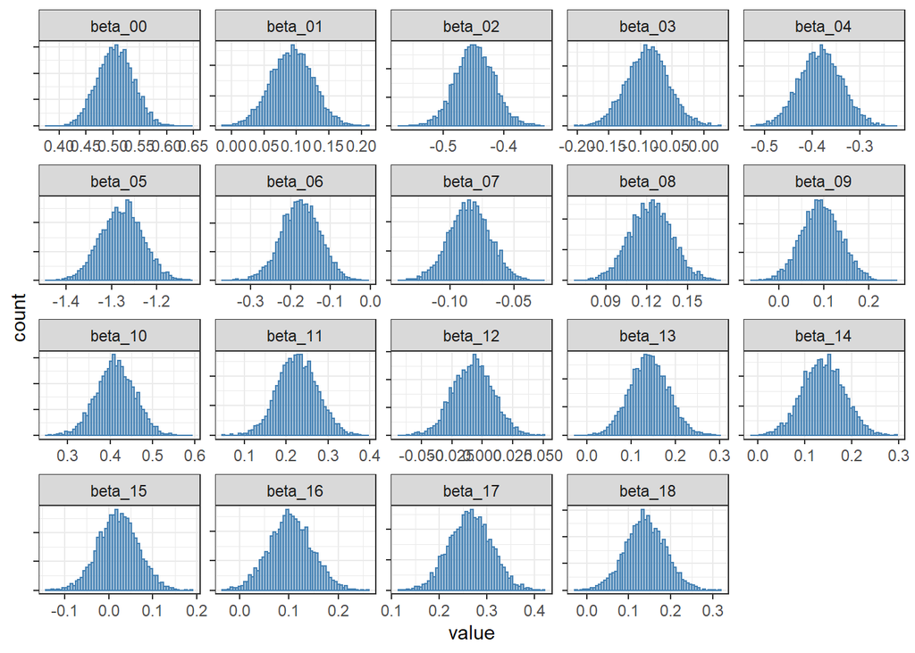

```r
post_samples_basis %>%
  select(-varphi, -sigma) %>%
  tibble::rowid_to_column('post_id') %>%
  tidyr::gather(key = 'key', value = 'value', -post_id) %>%
  ggplot(mapping = aes(x = value)) +
  geom_histogram(bins = 55, fill = 'steelblue', color = 'steelblue', alpha = 0.5) +
  facet_wrap(~key, scales = 'free') +
  theme_bw() +
  theme(axis.text.y = element_blank())
```

Show the correlations of the features.

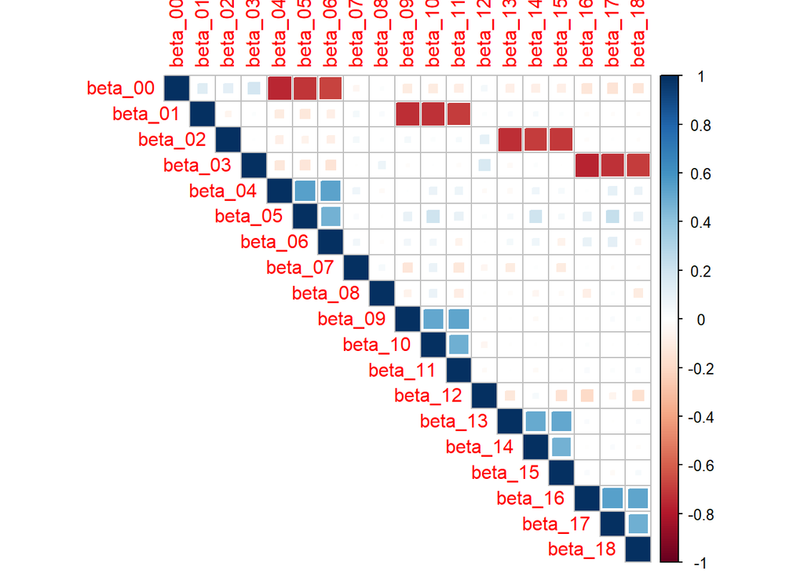

```r
post_samples_basis %>%
  select(-varphi, -sigma) %>%
  cor() %>%
  corrplot::corrplot(method = 'square', type = 'upper')
```

*Some of the coefficients seem to be highly correlated. I think it’s because of the categorical variables in the data set.*

## Study the uncertainty in the noise (residual error), $\sigma$.

The noise, $\sigma$, is the residual error of the model’s mean trend.

Display the residual error.

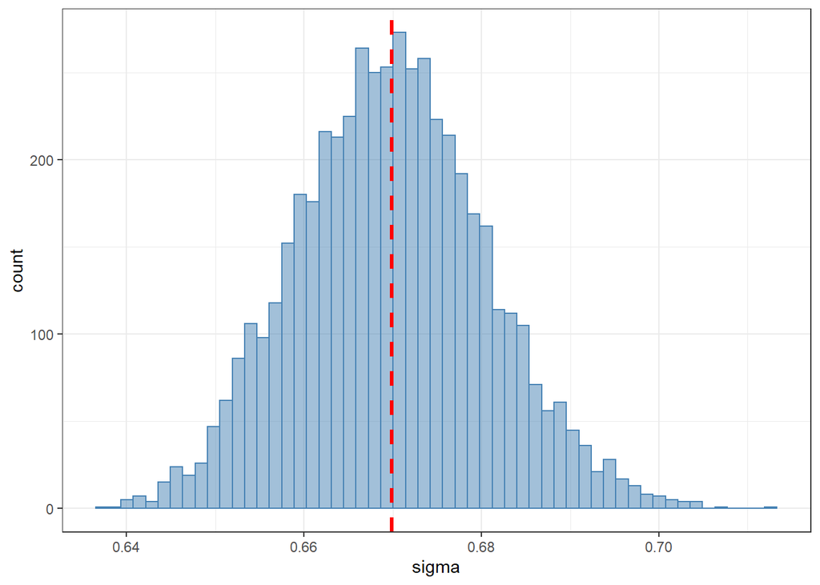

```r
post_samples_basis %>%
  select(sigma) %>%
  ggplot(mapping = aes(x = sigma)) +
  geom_histogram(bins = 55, fill = 'steelblue', color = 'steelblue', alpha = 0.5) +
  geom_vline(xintercept = mean(post_samples_basis$sigma), size = 1.2, color = 'red', linetype = 'dashed') +
  theme_bw()
```

##### How does the `lm()` maximum likelihood estimate (MLE) on $\sigma$ relate to the posterior uncertainty on $\sigma$?

The RMSE is the sigma, so we need to compare the RMSE to the $\sigma$.

Get the RMSE.

```r
RMSE_basis <- extract_metrics(mod_obj = mod_lm_basis, mod_name = 'mod_lm_basis')['sigma']
RMSE_basis
```

```
## # A tibble: 1 x 1
##   sigma
##   <dbl>
## 1 0.673
```

Get the posterior uncertainty on $\sigma$.

```r
post_samples_basis$sigma %>% mean()
```

```
## [1] 0.6698775
```

*As we can see, the MLE on $\sigma$ is really close to the posterior uncertainty on $\sigma$.*